# ANALYSIS OF SPATIO-TEMPORAL DATA

## FINAL PROJECT-2023

RAM KUMAR MUTHUSAMY

536951

02.08.2023

**HEALTH FACILITIES IN AMAZON REGION**

#### INTRODUCTION

The Amazon region of Brazil is an area with unique challenges for healthcare access due to its vast size, remote locations, and diverse population. In recent years, there has been a significant increase in the number of health facilities in the region. This trend raises questions about the factors driving the distribution of health resources and the impact of urbanization on the allocation of healthcare services.

The hypothesis of this analysis is "There is a significant positive relationship between the number of health facilities and population density/urbanization in the Amazon region of Brazil."

#### DATA

The dataset used here is geobr package. it provides access to several official spatial datasets from Brazil, including data on demographics, health, education, and more.

#### METHODS

This loadS required R packages for the analysis, including geobr, sf, spdep, and leaflet.

```r
suppressPackageStartupMessages(library(geobr))
suppressPackageStartupMessages(library(sf))
suppressPackageStartupMessages(library(spdep))
suppressPackageStartupMessages(library(leaflet))
suppressPackageStartupMessages(library(dplyr))
suppressPackageStartupMessages(library(spatstat))
suppressPackageStartupMessages(library(lwgeom))
```

reading data

```r
urban_2015 <- read_urban_area(year = 2015)
urban_2005 <- read_urban_area(year = 2005)
healthf <- read_health_facilities()
pop <- read_pop_arrangements(year=2015)
amazon <- read_amazon()
```

selecting data only from the Amazon region using the st_intersection() function. The urban areas in 2015 and 2005 are intersected with the Amazon region

```r
# make urban_2015 and urban_2005 valid
urban_2015 <- st_make_valid(urban_2015)
urban_2005 <- st_make_valid(urban_2005)
pop <- st_make_valid(pop)

pop_amazon <- st_intersection(pop, amazon)
urban_2015  <- st_intersection(urban_2015, amazon)
urban_2005  <- st_intersection(urban_2005, amazon)
health_amazon  <- st_intersection(healthf, amazon)
urban_change <- st_difference(urban_2015, urban_2005)
```

creating an interactive map of the Amazon region using the leaflet package. It shows the population distribution and the location of health facilities.

```r
h <- st_transform(health_amazon, "+proj=longlat +datum=WGS84")
pop84 <- st_transform(pop_amazon, "+proj=longlat +datum=WGS84")

m <- leaflet() %>%
  addTiles() %>%
  addPolygons(data = pop84, stroke = FALSE, fillOpacity = 0.3) %>%
  addCircleMarkers(data = h,
                   radius = 1,
                   color = "red",
                   stroke = FALSE,
                   fillOpacity = 0.8,
                   popup = paste("Health Facility : ", h$code_cnes))
m
```

[interactive chart not shown]

Convert the health facilities data to a point pattern object and perform a K-function analysis to determine if the distribution of health facilities is clustered or random.

```r
health_amazon_df <- st_drop_geometry(health_amazon)
coords <- st_coordinates(health_amazon$geom)
health_amazon_df$x <- coords[, "X"]
health_amazon_df$y <- coords[, "Y"]

W <- as.owin(st_bbox(urban_change))

health_ppp <- as.ppp(health_amazon_df[, c("x", "y")], W=W)

K <- Kest(health_ppp, correction = "border")
```

We perform a spatial point pattern analysis to explore the distribution of health facilities in the Amazon region of Brazil. We use the K-function to test whether the pattern of health facilities is random, clustered, or dispersed. We also compare the observed K-function to the expected K-function for a random pattern, and add a reference line to visually assess the degree of clustering or dispersion.

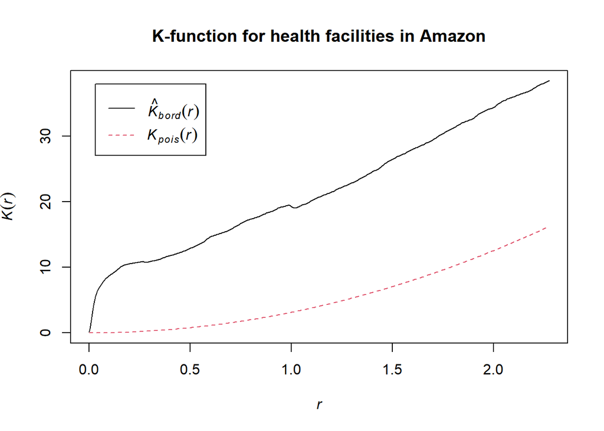

```r
plot(K, main = "K-function for health facilities in Amazon")
```

```r
r <- K$r
L <- sqrt(r/pi)
expected <- envelope(health_ppp, Kest, nsim = 99, correction = "border")
```

```
## Generating 99 simulations of CSR  ...
## 1, 2, 3, 4, 5, 6, 7, 8, 9, 10, 11, 12, 13, 14, 15, 16, 17, 18, 19, 20, 21, 22, 23, 24, 25, 26, 27, 28, 29, 30, 31, 32, 33, 34, 35, 36, 37, 38, 39, 40,
## 41, 42, 43, 44, 45, 46, 47, 48, 49, 50, 51, 52, 53, 54, 55, 56, 57, 58, 59, 60, 61, 62, 63, 64, 65, 66, 67, 68, 69, 70, 71, 72, 73, 74, 75, 76, 77, 78, 79, 80,
## 81, 82, 83, 84, 85, 86, 87, 88, 89, 90, 91, 92, 93, 94, 95, 96, 97, 98,  99.
##
## Done.
```

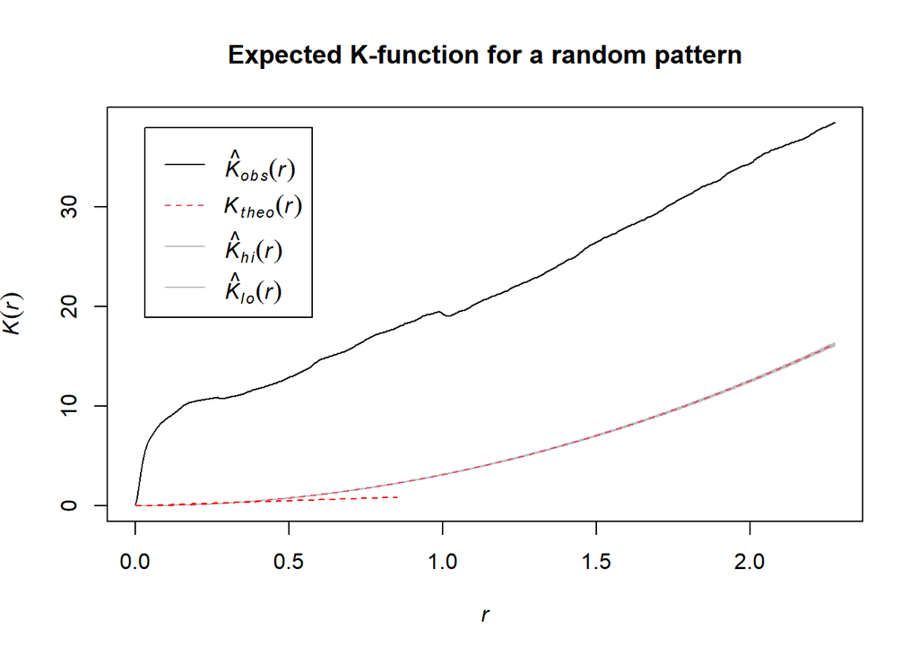

```r
plot(expected, main = "Expected K-function for a random pattern")
lines(L, L, col = "red", lty = 2)
```

#### REFERENCES

1. Spatial Point Pattern Analysis in R by Adrian Baddeley, Ege Rubak, and Rolf Turner (https://www.spatstat.org/book/)
2. Exploratory Spatial Data Analysis with R by Roger S. Bivand, Edzer J. Pebesma, and Virgilio Gómez-Rubio (https://bookdown.org/egarpor/ESDA/)
3. geobr (https://github.com/ipeaGIT/geobr)
4. sf (https://r-spatial.github.io/sf/)
5. Statistical Analysis of Spatial and Spatio-Temporal Point Patterns by Peter J. Diggle (https://www.routledge.com/Statistical-Analysis-of-Spatial-and-Spatio-Temporal-Point-Patterns/Diggle/p/book/9781032477473)